```r
## Pregunta sobre vuelo acrobático
## ===========================================
## Datos:
## nombre: vuelo_acrobatico
## tipo: schoice
## idioma: es
## respuesta: C
## solución: Según los tiempos e intervalos de la descripción del piloto, la gráfica C representa correctamente el vuelo.
```

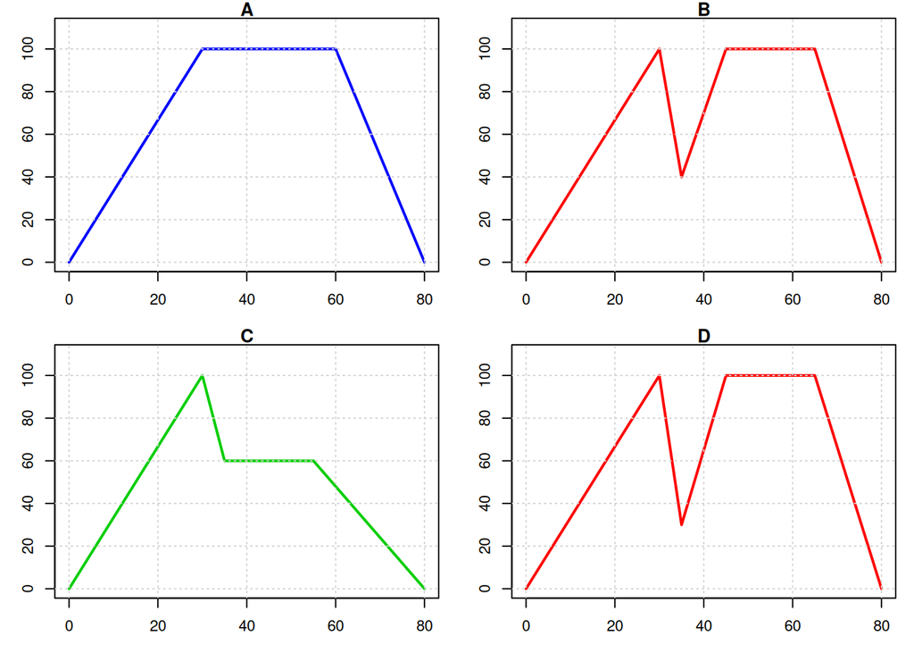

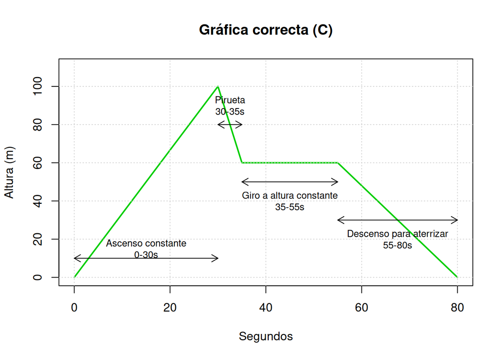

# Question

En una entrevista para una cadena de televisión, un piloto de un avión de acrobacias comenta en detalle cómo fue su presentación:

“Durante los primeros 30 segundos aumenté la altura de manera constante y luego, realicé una pirueta en la que descendí de manera constante durante 5 segundos. Después del descenso, comencé a girar en torno al eje del avión durante 20 segundos, manteniendo la misma altura. Para finalizar, aterricé reduciendo la altura de manera constante durante 25 segundos.”

¿Cuál de las siguientes gráficas representa de forma CORRECTA la información dada por el piloto?

# Solution

La respuesta correcta es **C**.

- A: Incorrecta: No muestra el descenso durante la pirueta (30-35s).
- B: Incorrecta: Muestra un ascenso después de la pirueta que no corresponde con ‘mantener la misma altura’.
- C: Correcta: Representa exactamente los intervalos descritos: ascenso (0-30s), descenso (30-35s), altura constante (35-55s) y descenso final (55-80s).
- D: Incorrecta: Muestra un ascenso después de la pirueta que no corresponde con la descripción.

La gráfica C representa correctamente la descripción del vuelo acrobático:

1. Durante los primeros 30 segundos, la altura aumenta de manera constante (línea con pendiente positiva).
2. Entre los segundos 30 y 35, durante la pirueta, hay un descenso constante (línea con pendiente negativa).
3. Entre los segundos 35 y 55, mientras gira alrededor del eje del avión, mantiene la misma altura (línea horizontal).
4. Finalmente, desde el segundo 55 hasta el 80, reduce la altura de manera constante para aterrizar (línea con pendiente negativa).

# Meta-information

exname: Vuelo acrobático extype: schoice exsolution: 0010 exshuffle: TRUE